# act_report

## Report: act_report

- Create a **250-word-minimum written report** called "act_report.pdf" or "act_report.html" that communicates the insights and displays the visualization(s) produced from your wrangled data. This is to be framed as an external document, like a blog post or magazine article, for example.

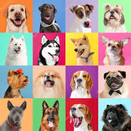

##### This act report includes the summary of the Data Analysis process that was taken for the data wrangling project undertaken.

For this project, I worked with three datasets.

Udacity provided the first dataset as a csv file named twitter_archive_enhanced.csv. It contained basic information of about 2356 tweets and it was downloaded manually.

The second dataset was a tsv file named image_prediction.tsv, which was hosted on the udacity server and had to be programmatically downloaded. It contained 2075 image predictions made by a neural network that can identify dog breeds.

The third and final dataset was scrapped from the twitter API using python Tweepy’s Library. This third dataset contained information like the retweet count, favorite count, followers count and friends count for each tweet with 2327 tweets saved into a file named "tweet_json_text".

During the data aassessment stage, 11 data quality issues and 4 data tidiness issues were found respectively in the three datasets. A variety of Pandas methods were used to assess and clean these issues found in the datasets.

##### Some insights and visualizations from the three datasets that were merged into a master dataset named twitter_archive_master.csv.

Insights from the master dataset were made by displaying a descriptive statistics of the dataset to know the count, mean, minimum and maximum values and percentiles for each numeric column.

```python
import pandas as pd
data = pd.read_csv('twitter_archive_master.csv')
```

```python
data.describe()
```

|  | tweet_id | rating_numerator | rating_denominator | img_num | p1_conf | p2_conf | p3_conf | retweet_count | favorite_count |
| --- | --- | --- | --- | --- | --- | --- | --- | --- | --- |
| count | 1.986000e+03 | 1986.000000 | 1986.000000 | 1986.000000 | 1986.000000 | 1.986000e+03 | 1.986000e+03 | 1986.000000 | 1986.000000 |
| mean | 7.356142e+17 | 12.281974 | 10.534240 | 1.203424 | 0.593452 | 1.344853e-01 | 6.034994e-02 | 2241.498993 | 7706.313696 |
| std | 6.740686e+16 | 41.581180 | 7.335369 | 0.561492 | 0.271961 | 1.005944e-01 | 5.091948e-02 | 4015.418972 | 11368.456459 |
| min | 6.660209e+17 | 0.000000 | 2.000000 | 1.000000 | 0.044333 | 1.011300e-08 | 1.740170e-10 | 11.000000 | 66.000000 |
| 25% | 6.758214e+17 | 10.000000 | 10.000000 | 1.000000 | 0.362656 | 5.407533e-02 | 1.624755e-02 | 494.250000 | 1635.500000 |
| 50% | 7.082494e+17 | 11.000000 | 10.000000 | 1.000000 | 0.587357 | 1.175370e-01 | 4.952715e-02 | 1078.500000 | 3462.500000 |
| 75% | 7.873791e+17 | 12.000000 | 10.000000 | 1.000000 | 0.844920 | 1.951377e-01 | 9.166433e-02 | 2554.500000 | 9556.000000 |
| max | 8.924206e+17 | 1776.000000 | 170.000000 | 4.000000 | 1.000000 | 4.880140e-01 | 2.734190e-01 | 70662.000000 | 144785.000000 |

```python
data.info()
```

```
<class 'pandas.core.frame.DataFrame'>
RangeIndex: 1986 entries, 0 to 1985
Data columns (total 21 columns):
 #   Column              Non-Null Count  Dtype
---  ------              --------------  -----
 0   tweet_id            1986 non-null   int64
 1   timestamp           1986 non-null   object
 2   source              1986 non-null   object
 3   text                1986 non-null   object
 4   rating_numerator    1986 non-null   int64
 5   rating_denominator  1986 non-null   int64
 6   name                1986 non-null   object
 7   stage               305 non-null    object
 8   jpg_url             1986 non-null   object
 9   img_num             1986 non-null   int64
 10  p1                  1986 non-null   object
 11  p1_conf             1986 non-null   float64
 12  p1_dog              1986 non-null   bool
 13  p2                  1986 non-null   object
 14  p2_conf             1986 non-null   float64
 15  p2_dog              1986 non-null   bool
 16  p3                  1986 non-null   object
 17  p3_conf             1986 non-null   float64
 18  p3_dog              1986 non-null   bool
 19  retweet_count       1986 non-null   int64
 20  favorite_count      1986 non-null   int64
dtypes: bool(3), float64(3), int64(6), object(9)
memory usage: 285.2+ KB
```

#### Insights

- favorite count had a minimum value of 66, a mean of 7706, and a maximum favorite count value of 144785
- retweet count had a minimum value of 11, mean is 2241, and the maximum retweet count is 70662
- Approximately 32% of the all dogs in the dataset had no names
- Image number 1 had the highest frequency among all images in the neural network's image predictions
- The merged dataset has 1986 rows and 21 columns, all the rows except for the `stage` column which is a combined column for all the dog stages are completely filled with no missing values.
- The columns in our master dataset are 'tweet_id', 'timestamp', 'source', 'text', 'rating_numerator', 'rating_denominator', 'name', 'stage', 'jpg_url', 'img_num', 'p1', 'p1_conf', 'p1_dog', 'p2', 'p2_conf', 'p2_dog', 'p3', 'p3_conf', 'p3_dog', 'retweet_count', 'favorite_count'.

#### Visualizations

1. The most popular dog stage according to the neural network's image prediction

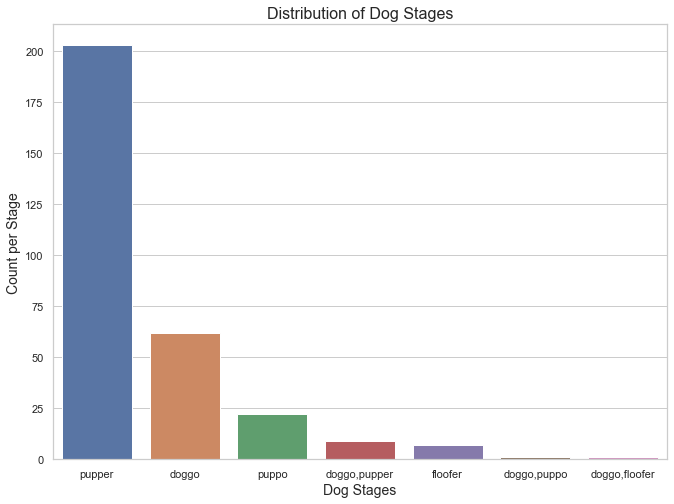

- The most popular dog stage that was rated by the WeRateDogs Twitter account was pupper, follwed by doggo, then puppo, doggo,pupper, floofer, doggo,puppo and doggo,floofer.
1. The most popular dog breeds(top 10)

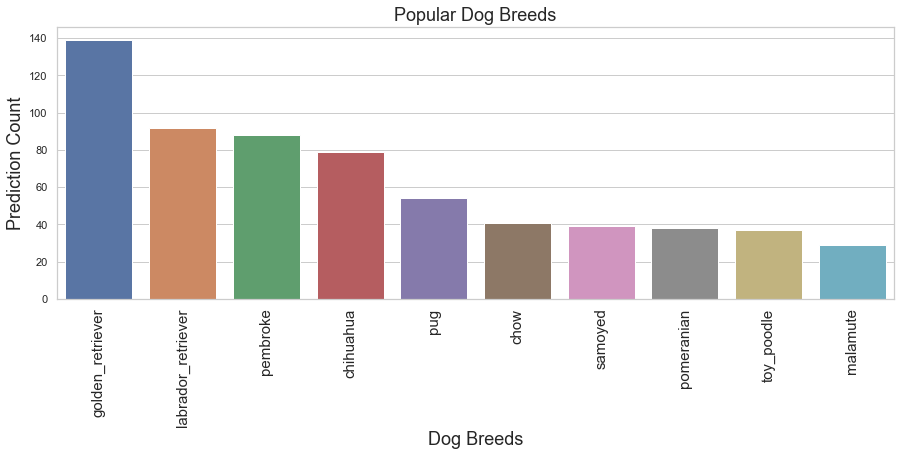

- The most popular dog breed from the WeRateDogs Twitter account was a golden retriever.
1. Type of correlation or relation between retweet count and favourite count

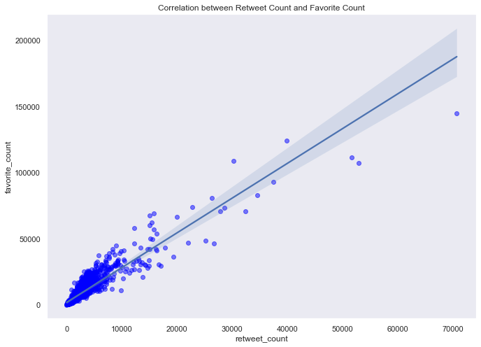

- From the graph above, there is a positive correlation or linear relation between retweet_count and favorite_count. Meaning that the most popular tweets get the highest number of retweet count and favorite count.
1. The source with the highest proportion of tweets on the WeRateDog twitter account

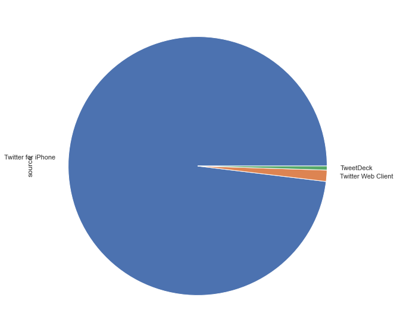

- The pie chart above shows that Twitter from iPhone was the source that contributed the most tweets and there had the highest proportion of all the sources

##### This concludes the summary of the Data Wrangling process of data gathered from the WeRateDogs twitter account

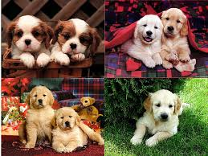